# Text Mining

Alun

12 March 2016

# Building Term Document Matrix

### Extract individual words from html:

Using the “//span[@class='ocr_cinfo']” tag. Objects with this tag are in two paragraphs per page, the first being the title and second being the text. We remove the title of each page and focus only on the text. Build a corpus, with each document being a book. Joining each page of seperate words together into a book and each book together into a corpus.

### Preprocessing:

The preprocessing of the corpus is described by the steps below. Steps in brackets were implemented later.

- Load the corpus
- Tokenise
- Remove stop words
- Case folding
- Class equivalence
- (ngrams)
- (extra stop word removal)

Produces a **sparse document term matrix** (with large maximal term length). For computational reasons we remove sparse terms. Here we choose to **remove any term which only appears in one document**, as it can’t help link that document to another, which is our goal.

```
## <<DocumentTermMatrix (documents: 24, terms: 36595)>>
## Non-/sparse entries: 226796/651484
## Sparsity           : 74%
## Maximal term length: 19
## Weighting          : term frequency (tf)
```

The **sparsity has deceased** and the maximum term length is something more reasonable. We can view the most frequent terms of each book to see which terms are highly weighted.

|  | 1 | 2 | 3 | 4 | 5 | 6 | 7 | 8 | 9 | 10 |
| --- | --- | --- | --- | --- | --- | --- | --- | --- | --- | --- |
| Geo Dictionary | whch | wth | ths | name | hae | town | ther | place | call | cti |
| Tacitus Hist 3 | wth | ther | book | otho | ths | solder | tellus | legon | tme | men |
| Pelopennesian 2 | ther | wth | ths | athenan | whch | upon | now | hae | nto | lacedmonan |
| Livy 1 | ther | wth | whch | roman | hae | emperor | ths | nto | empr | senat |
| Decline & Fall 3 | ther | wth | whch | ths | con | beng | roman | trbune | hae | cti |
| Josephus 2 | ther | ths | wth | whch | kng | also | hae | upon | great | made |
| Description of Greece | ther | wth | whch | torn | ths | hae | roman | year | mght | thousand |
| Livy 3 | ths | whch | wth | son | call | ther | statu | cti | hae | god |
| Decline & Fall 4 | wth | whch | roman | ther | ths | senat | een | nto | rome | war |
| Decline and Fall 2 | ther | wth | whch | ths | roman | consul | beng | nto | hae | enemi |
| Tacitus Annals 1 | ther | wth | ths | whch | athenan | hae | upon | now | nto | war |
| Livy 5 | ther | wth | whch | chap | roman | ths | emperor | hae | mght | justnan |
| Josephus 1 | ther | whch | wth | julan | chap | emperor | roman | ths | hae | mght |
| Decline & Fall 5 | ther | wth | ths | whch | peopl | consul | trbune | hae | roman | cti |
| Tacitus Hist | wth | ther | ths | tberus | tme | whch | men | germancus | roman | made |
| Decline & Fall 6 | ther | wth | ths | whch | upon | hae | jew | also | great | now |
| Decline & Fall 1 | wth | nero | ther | book | see | ths | whch | lfe | tme | emperor |
| History of Rome 3 | wth | ther | whch | roman | ths | nto | consul | order | war | beng |
| Pelopennesian 1 | ths | ther | wth | whch | god | upon | hae | kng | also | great |
| Livy History | ths | whch | wth | hae | gold | sler | use | call | ther | also |
| Josephus 4 | ther | wth | whch | roman | ths | hae | justnan | mght | year | emperor |
| Tacitus Hist 4 | note | wth | whch | ths | non | sed | ther | cum | per | quam |
| Pliny Nat. Hist | ther | wth | whch | torn | ths | hae | year | frst | hundr | greek |
| Josephus 3 | ther | wth | ths | whch | upon | also | great | hae | now | men |

Looking at the frequency table again…

|  | 1 | 2 | 3 | 4 | 5 | 6 | 7 | 8 | 9 | 10 |
| --- | --- | --- | --- | --- | --- | --- | --- | --- | --- | --- |
| Geo Dictionary | strab | ptol | steph | dentf | pln | comp | aegypt | tab | dod | herod |
| Tacitus Hist 3 | otho | caecna | lego | tellus | galba | secton | tellan | othonan | bedracum | praetoran |
| Pelopennesian 2 | lacedmonan | syracusan | arg | alcbad | tssaphern | athenan | ncas | peloponnesan | lacedmon | gylppus |
| Livy 1 | prtoran | docletan | mamn | chrstan | constantnopl | aurelan | maman | probus | csar | galerus |
| Decline & Fall 3 | thefe | ftate | alfo | fome | moft | afembl | foon | whofe | poft | muft |
| Josephus 2 | herod | hyrcanus | jew | arstobulus | jonathan | judea | jerusalem | josephus | antpat | juda |
| Description of Greece | justnan | constantnopl | belsarus | mahomet | calph | saracen | heraclus | mecca | lombard | procopus |
| Livy 3 | fay | statuari | theban | lacedmonan | delpho | proclus | puglst | nymph | dmon | olympc |
| Decline & Fall 4 | sulla | burgess | gracchus | gaus | carbo | marus | communt | jugurtha | epoch | fnancal |
| Decline and Fall 2 | samnt | etruran | samnum | honor | consul | hannbal | paprus | decus | etrura | pretor |
| Tacitus Annals 1 | lacedaemonan | corcyrean | peloponnesan | brasda | athenan | hath | plataean | thucydd | megarean | boeotan |
| Livy 5 | belsarus | justnan | constantnopl | heraclus | lombard | chosro | chap | gothc | goth | saracen |
| Josephus 1 | constantus | constantnopl | theodosus | alentnan | gratan | julan | ammanus | chap | goth | zosmus |
| Decline & Fall 5 | olsc | jequ | rgnus | decemr | qunctus | etruran | consul | appus | tarqun | chap |
| Tacitus Hist | germancus | armnus | drusus | csecna | pso | cheruscan | plancna | segest | csesar | tacfarna |
| Decline & Fall 6 | josephus | jew | herod | jerusalem | dumean | hath | ananus | judea | smon | jesus |
| Decline & Fall 1 | nero | appen | corbulo | slanus | thrasea | suet | lepda | trdate | jula | nymphdus |
| History of Rome 3 | masnssa | pretor | sypha | hasdrub | attalus | hannbal | carthagnan | laelus | quntus | bruttum |
| Pelopennesian 1 | saul | dad | josephus | herod | hyrcanus | jonathan | mose | hghprest | hebrew | phlstnes |
| Livy History | lbs | mnum | alpi | rngs | copper | lond | doscord | qucksler | foss | electrum |
| Josephus 4 | justnan | belsarus | gothc | goth | procopus | constantnopl | theodorc | chosro | heraclus | pandect |
| Tacitus Hist 4 | subj | etc | tello | quam | nequ | nec | eerctus | rup | othon | bellum |
| Pliny Nat. Hist | mahomet | calph | saracen | constantnopl | mecca | moslem | medna | bblot | patrarch | arab |
| Josephus 3 | herod | antpat | jew | pherora | arstobulus | hyrcanus | tbera | archelaus | judea | hghprest |

We can see now using term frequency - inverse document frequency (tf-idf) that the **highest weighted terms are now primarily names**. herod, justinian etc. This is suggestive that the clustering later will be about the people and places (names) associated with those books.

### Calculate dissimilarity matrix

Finally we calculate a distance measure. In this case we use cosine similarity. Use matrix package to manipulate sparse matrix. Otherwise computer doesn’t have enough memory.

# Heirarchical clustering

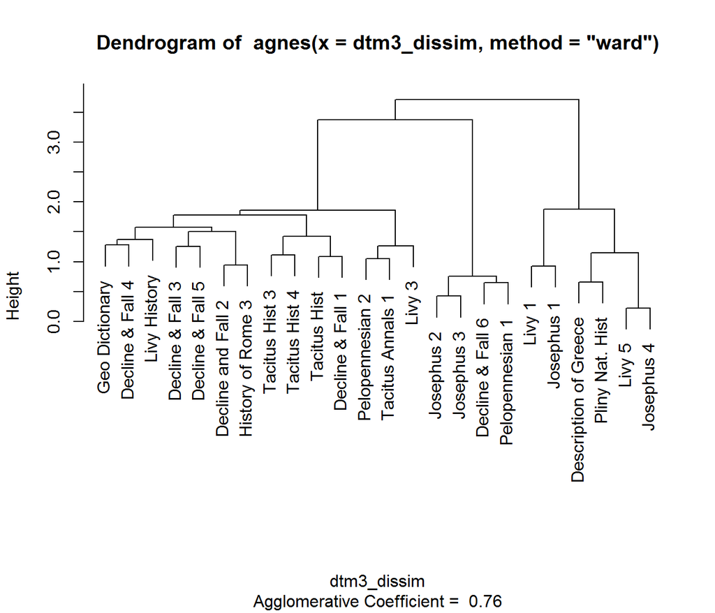

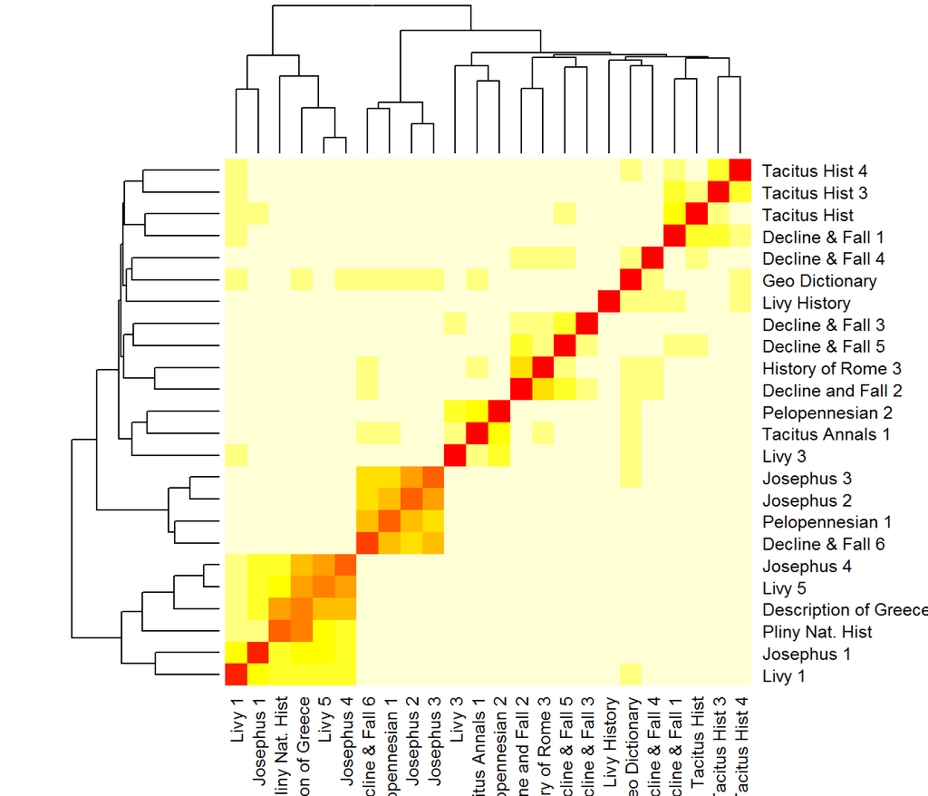

We can see the dictionary isn’t appropriately being isolated. This is likely because we got rid of the sparse terms. The thing that made the dictionary so distinct for other text is that it has a large set of terms which are all mentioned only once. **can we do it without removing sparsity?**

We can also see that the different set of books are sometimes but not consistently grouped together by any of these methods. An example in the HDS graph is Livy I and Jospehus I being grouped together.

After trying many of the different methods and both manhattan and euclidean distance, the clusters never change with the exception of single linkage, where Livy History has its own cluster.

From the heatmap, where dissimilarity is yellow and similarity is red. You can see the documents are quite dissimilar with few exceptions.

In summary the clustering seems to have done a reasonable job at joining similar topics together, primarily by isolating names and topics of the text. However it hasn’t clustered together similar authors or writing styles. For this you would want to look at the more frequent terms in each document. Also using tf-idf likely has a negative impact in this regard because words that are similar across 6 books.

## Ngrams

We find with trigrams many of the highly weighted trigrams come from printing constructs such as “na na book” or “vol ii p”. To counter this we remove letters, roman numerals and ‘na’ from our corpus. On the positive side less of these are based on names.

## Dense terms

As seen before we clustered reatively well by topic but not the books of the same author. You imagine that the specific language of the author would be more heavily related to the text. Inverse document frequency however removes a lot of this effect because the author clusters are large portions of the data and language terms like “beautiful” may be quite common.

So to try and analyse the language and cluster the authors, we remove a lot more of the sparsity and don’t use idf. # Although we do still normalise so clusters aren’t dependent on book length. (don’t because don’t know how)

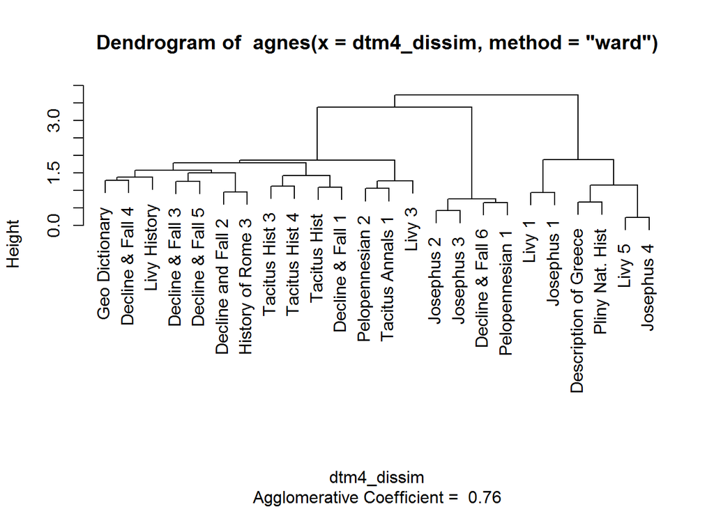

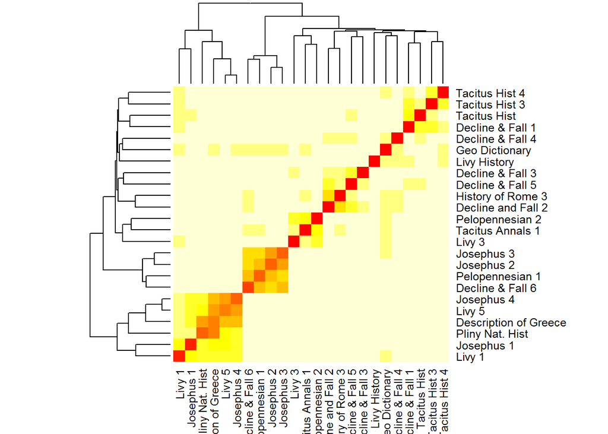

## K means

Spherical k means clustering works on cosine similarity as well.

# High dimensional scaling

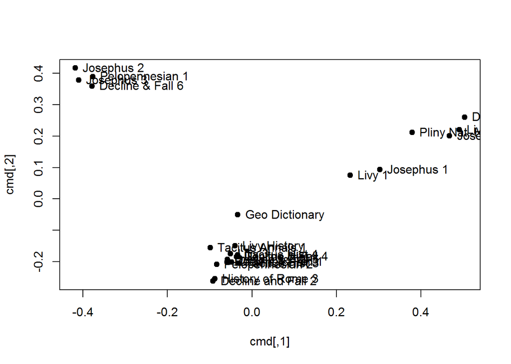

# PCA

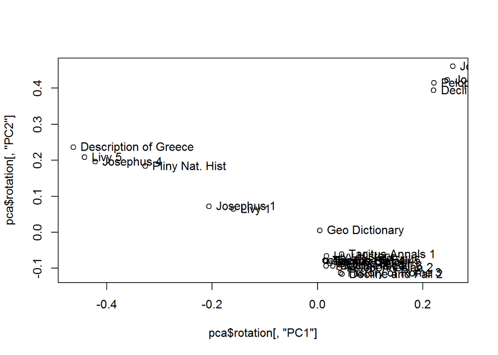

# Self organised maps

# Found that a small cluster Josephus I and Livy I were based around an alternate stemming of constantinople.

By joining constantn and constantnopl they join the cluster on the right. (Checked that they were describing contantnople not something different like constantine first.)

The cluster on the right is th most dissimilar cluster. So we can see how the clusters can be heavily influenced by a single word.

This also suggests that the sparsity tollerated was probably too low.